# Lab 11: Simulation and Power Analysis

Elyse McCormick

2022-12-06

**Q1 (2 pts.): Include a figure of your line plot in your report.**

```
## here() starts at C:/Users/elyse/Documents/University of Massachusetts/ECO_602/environmental_data
```

[output not shown]

[output cut: 83 more lines]

[output not shown]

[output cut: 20 more lines]

[output not shown]

[output cut: 111 more lines]

```
## [1] 0.1412668
```

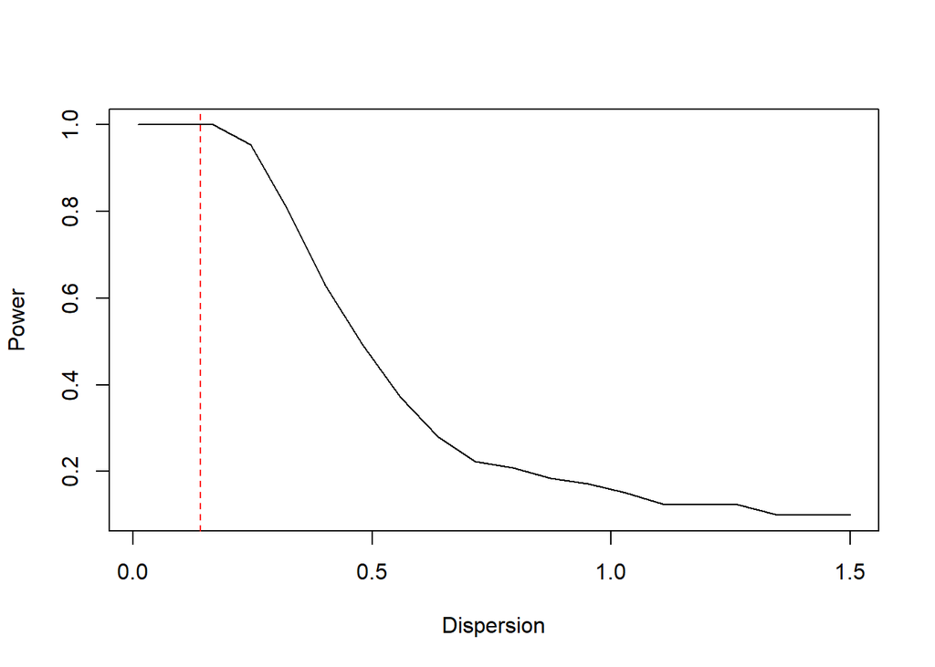

**Q2 (2 pts.): Why do you think that statistical power decreases as population dispersion increases?**

Because there’s more variation. If there’s a high amount of variation, then statistical power isn’t centering on a mean, which indicates your data are dissimilar, ultimately decreasing your statistical power and confidence.

**Q3 (2 pts.): Include a figure of your contour plot in your report.**

```r
alpha = 0.05
effect_size = 0.01

# Start with a small number
n_sims = 10
p_vals = numeric(n_sims)

# What was the observed standard deviation?
sd_obs
```

```
## [1] 0.1412668
```

```r
# specify the number of different standard deviation values to simulate:
# Start with a small number
n_sds = 20
pop_sds = seq(from = 0.05, to = 1.5, length.out = n_sds)

# The maximum x value in the simulation.
# Use the maximum observed x-value in the data
max_x = max(birdhab$ls)

pop_sd_powers = numeric(length(pop_sds))

sample_sizes = seq(5, 100)

sim_output_3 = matrix(nrow = length(pop_sds), ncol = length(sample_sizes))


for(k in 1:length(pop_sds))
{
  pop_sds_k = pop_sds[k]

  for(j in 1:length(sample_sizes))
  {
    x_vals = seq(0, max_x, length.out = sample_sizes[j])

    for(i in 1:n_sims)
    {
      fit_sim = linear_sim_fit(
        x = x_vals,
        y_int = int_obs,
        slope = effect_size,
        st_dev = pop_sds_k
      )
      p_vals[i] = summary(fit_sim)$coefficients[2, 'Pr(>|t|)']
    }

    sim_output_3[k, j] = sum(p_vals < alpha) / n_sims
  }
  print(paste0("Testing standard deviation ", k, " of ", n_sds))
}
```

```
## [1] "Testing standard deviation 1 of 20"
## [1] "Testing standard deviation 2 of 20"
## [1] "Testing standard deviation 3 of 20"
## [1] "Testing standard deviation 4 of 20"
## [1] "Testing standard deviation 5 of 20"
## [1] "Testing standard deviation 6 of 20"
## [1] "Testing standard deviation 7 of 20"
## [1] "Testing standard deviation 8 of 20"
## [1] "Testing standard deviation 9 of 20"
## [1] "Testing standard deviation 10 of 20"
## [1] "Testing standard deviation 11 of 20"
## [1] "Testing standard deviation 12 of 20"
## [1] "Testing standard deviation 13 of 20"
## [1] "Testing standard deviation 14 of 20"
## [1] "Testing standard deviation 15 of 20"
## [1] "Testing standard deviation 16 of 20"
## [1] "Testing standard deviation 17 of 20"
## [1] "Testing standard deviation 18 of 20"
## [1] "Testing standard deviation 19 of 20"
## [1] "Testing standard deviation 20 of 20"
```

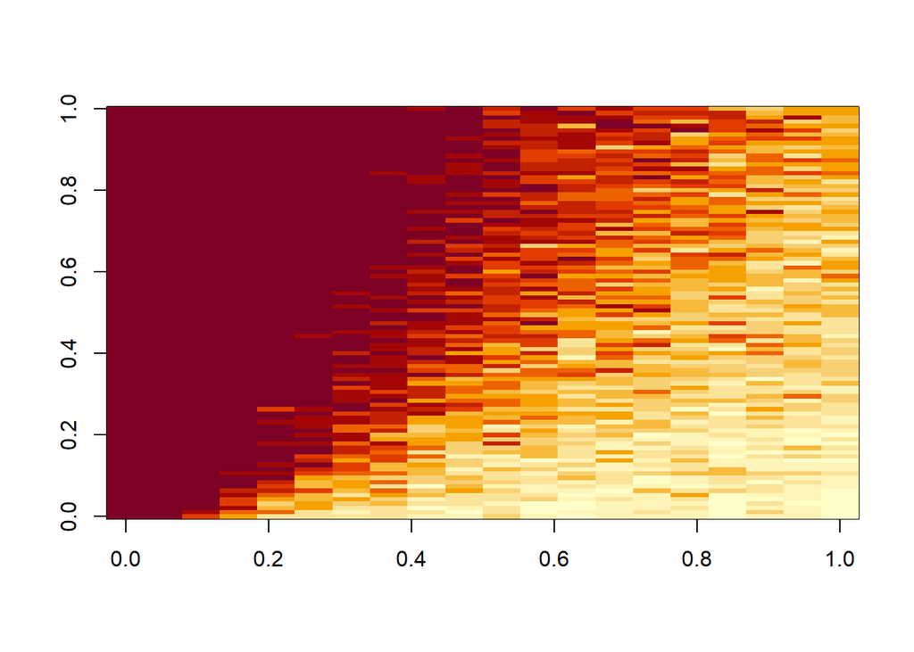

```r
image(sim_output_3)
```

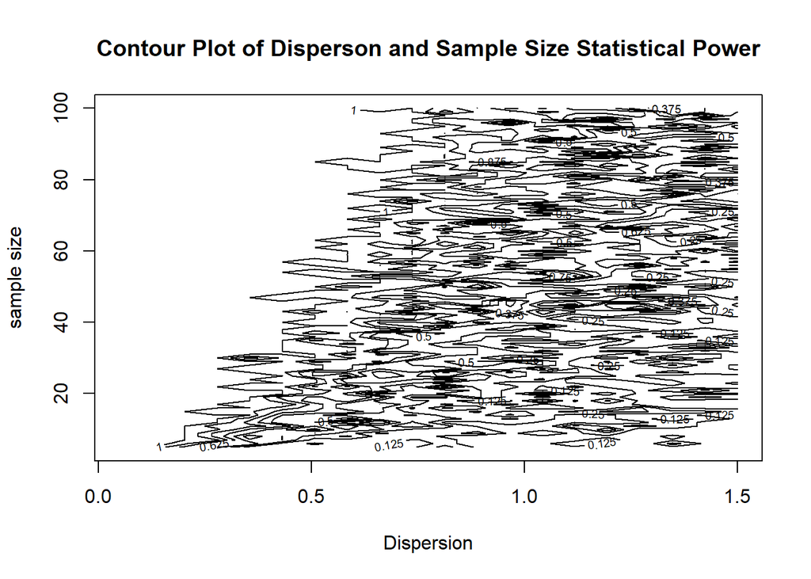

```r
sim_3_dat =
  list(
    power       = sim_output_3,
    sample_size = sample_sizes,
    pop_sd      = pop_sds)


# You should save your simulation results so you don't have to run it every time.
save(
  sim_3_dat,
  file = here::here("data", "lab_ll_sim_output_dispersion_n_1000.RData"))

# Contour plot

contour(
  x = sim_3_dat$pop_sd,
  y = sim_3_dat$sample_size,
  z = sim_3_dat$power,
  xlab = "Dispersion",
  ylab = "sample size",
  main = "Contour Plot of Disperson and Sample Size Statistical Power",
  levels = seq(0, 1, length.out = 9),
  drawlabels = TRUE,
  # method = "simple")
  method = "edge")
```

**Q4 (2 pts.): Qualitatively describe the patterns you see in the contour plot. Make sure you discuss the effects of sample size and population dispersion on statistical power.**

**Q5 (5 pts.): Upload your plot as an interactive html html file. NOTE: some Mac users are not able to use RGL. You may also upload a static plot created with persp() if you can’t get RGL to work on your computer.**

```r
require("rgl")
```

```r
persp3d(
  x = sim_3_dat$pop_sd,
  y = sim_3_dat$sample_size,
  z = sim_3_dat$power,
  xlab = "Dispersion", ylab = "Sample Size", zlab = "Power",
  col = 'lightblue',
  theta = 30, phi = 30, expand = 0.75,
  ticktype = 'detailed')
```

[output not shown]

**Q6 (2 pts.): Describe how you could use the information shown in your plot when designing an experiment.**

I think this is useful when trying to understand why you may need a high sample size in your experimental design. This would indicate that increased sample size won’t eliminate your variation, but it will reduce it and increase the power of your design.